# Build a transfer learning model to classify the Yoga poses 107 dataset - https://www.kaggle.com/datasets/arrowe/yoga-poses-dataset-107

# Perform exploratory data analysis and data cleaning as necessary.

under this folder C:\Users\gongl1\Desktop\Advanced Computer Vision_Pujari\Assignment2\archive (18)\107 yoga poses, I have 3 sub folders - test, train, val, each has 107 subfolders that representing 107 yoga poses. In each subfolder, it includes PNG images showing a certain yoga pose. I want to Build a deep learning model to classify the Yoga poses 107 dataset. First, Perform exploratory data analysis and data cleaning as necessary.

# Load the Data

```python
import os
from pathlib import Path
from PIL import Image
import matplotlib.pyplot as plt
```

```python
# Mount Google Drive
from google.colab import drive
drive.mount('/content/drive')
```

```python
# Define the paths
base_dir = Path("/content/drive/My Drive/Colab Notebooks/Computer Vision and Deep Learning/107 yoga poses")
train_dir = base_dir / "train"
val_dir = base_dir / "val"
test_dir = base_dir / "test"
```

```python
# Function to load images
# Recursively goes through the given folder.
# Reads and loads images from each subfolder.
# Assigns the name of the subfolder as the label for each image.
# Returns two lists: one with the image objects and one with the corresponding labels.
def load_images_from_folder(folder):
    images = []
    labels = []
    for label_dir in os.listdir(folder):
        if not os.path.isdir(os.path.join(folder, label_dir)):
            continue
        label = label_dir
        # The function iterates over each item in the specified folder using os.listdir(folder).
        # For each item (label_dir), it checks if it is a directory using os.path.isdir(os.path.join(folder, label_dir)).
        # If the item is not a directory, it skips to the next iteration with continue.
        # If the item is a directory, it assigns the directory name to the variable label, which will be used as the label for the images within that directory.

        for filename in os.listdir(os.path.join(folder, label_dir)):
            img_path = os.path.join(folder, label_dir, filename)
            try:
                img = Image.open(img_path)
                images.append(img)
                labels.append(label)
            except:
                print(f"Error loading image: {img_path}")
        # For each label_dir, the function iterates over the files inside that directory.
        # It constructs the full path to each image file using os.path.join(folder, label_dir, filename).
        # It then tries to open the image using Image.open(img_path).
        # If the image is successfully opened, it is appended to the images list, and the corresponding label is appended to the labels list.
        # If there is an error opening the image (e.g., the file is corrupted or not an image), it catches the exception and prints an error message indicating the problematic file.

    return images, labels
    # After iterating through all the subfolders and files, the function returns two lists: images (containing the loaded image objects) and labels (containing the corresponding labels for each image).


# Load data
train_images, train_labels = load_images_from_folder(train_dir)
val_images, val_labels = load_images_from_folder(val_dir)
test_images, test_labels = load_images_from_folder(test_dir)

print(f"Loaded {len(train_images)} training images, {len(val_images)} validation images, and {len(test_images)} test images.")
```

```
Loaded 4150 training images, 1157 validation images, and 687 test images.
```

```python
# test_images
```

```python
# test_labels
```

# Explore the Data

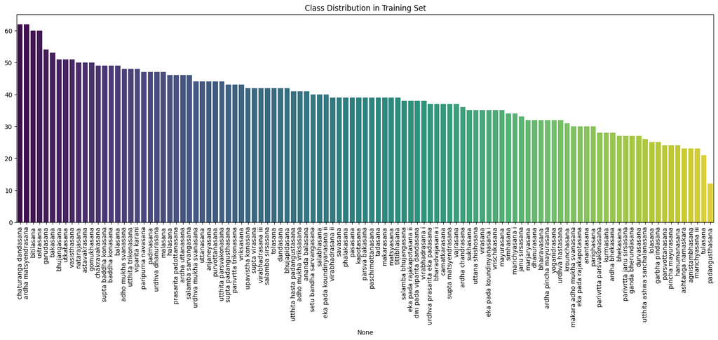

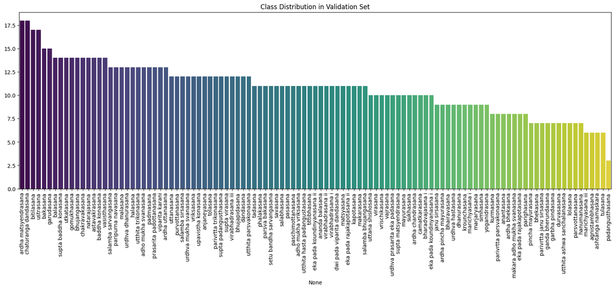

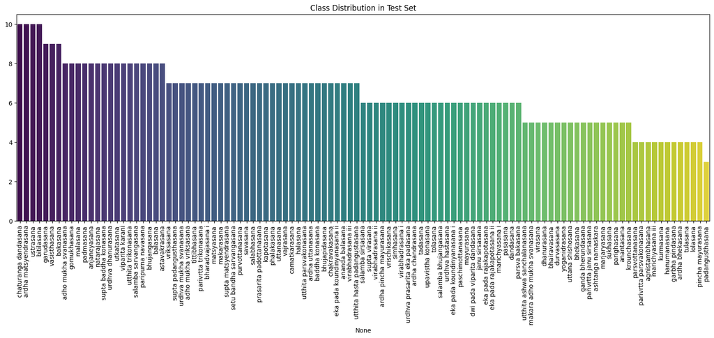

```python
import pandas as pd
import seaborn as sns

# Function to get distribution of classes
def get_class_distribution(labels):
    return pd.Series(labels).value_counts()

# Get distributions
train_dist = get_class_distribution(train_labels)
val_dist = get_class_distribution(val_labels)
test_dist = get_class_distribution(test_labels)

# Plot distributions
plt.figure(figsize=(20, 6))
sns.barplot(x=train_dist.index, y=train_dist.values, palette="viridis")
plt.title("Class Distribution in Training Set")
plt.xticks(rotation=90)
plt.show()

plt.figure(figsize=(20, 6))
sns.barplot(x=val_dist.index, y=val_dist.values, palette="viridis")
plt.title("Class Distribution in Validation Set")
plt.xticks(rotation=90)
plt.show()

plt.figure(figsize=(20, 6))
sns.barplot(x=test_dist.index, y=test_dist.values, palette="viridis")
plt.title("Class Distribution in Test Set")
plt.xticks(rotation=90)
plt.show()
```

# Ensure all images are of the same size and check for any corrupted images.

```python
import numpy as np
from PIL import Image

# Function to check and resize images
def check_and_resize_images(images, target_size=(224, 224)):
    cleaned_images = []
    for img in images:
        try:
            # Convert image to RGB format
            img = img.convert("RGB")
            # Resize image
            img = img.resize(target_size)
            # Convert image to NumPy array and append
            cleaned_images.append(np.array(img))
        except Exception as e:
            print(f"Error processing image: {e}")
            continue
    return np.array(cleaned_images)

# Clean and resize images
train_images_cleaned = check_and_resize_images(train_images)
val_images_cleaned = check_and_resize_images(val_images)
test_images_cleaned = check_and_resize_images(test_images)

print(f"After cleaning, we have {len(train_images_cleaned)} training images, {len(val_images_cleaned)} validation images, and {len(test_images_cleaned)} test images.")
```

```
After cleaning, we have 4150 training images, 1157 validation images, and 687 test images.
```

```python
test_images_cleaned.shape
```

```
(687, 224, 224, 3)
```

```python
# test_images_cleaned
```

# Prepare the Data for Modeling

# Prepare the data for modeling by normalizing the images and converting labels to numerical format.

```python
from sklearn.preprocessing import LabelEncoder
from tensorflow.keras.utils import to_categorical

# Normalize images
train_images_normalized = train_images_cleaned / 255.0
val_images_normalized = val_images_cleaned / 255.0
test_images_normalized = test_images_cleaned / 255.0

# Encode labels
label_encoder = LabelEncoder()
train_labels_encoded = label_encoder.fit_transform(train_labels)
val_labels_encoded = label_encoder.transform(val_labels)
test_labels_encoded = label_encoder.transform(test_labels)

# Convert labels to categorical
train_labels_categorical = to_categorical(train_labels_encoded)
val_labels_categorical = to_categorical(val_labels_encoded)
test_labels_categorical = to_categorical(test_labels_encoded)
```

```python
test_images_normalized.shape
```

```
(687, 224, 224, 3)
```

```python
test_labels_encoded.shape
```

```
(687,)
```

```python
test_labels_categorical.shape
```

```
(687, 107)
```

```python
test_labels_categorical
```

```
array([[0., 0., 0., ..., 0., 0., 0.],
       [0., 0., 0., ..., 0., 0., 0.],
       [0., 0., 0., ..., 0., 0., 0.],
       ...,
       [0., 0., 0., ..., 1., 0., 0.],
       [0., 0., 0., ..., 1., 0., 0.],
       [0., 0., 0., ..., 1., 0., 0.]], dtype=float32)
```

# Split the Dataset

We have already got the following train/val/test datasets

train_images_normalized

val_images_normalized

test_images_normalized

train_labels_categorical

val_labels_categorical

test_labels_categorical

Let's just use those instead of train-test split again.

# Load pre-trained model - Choose one of the pre-trained models (VGG16, ResNet50, or EfficientNetB0) and freeze its layers

```python
import tensorflow as tf
from tensorflow.keras.applications import VGG16, ResNet50, EfficientNetB0
from tensorflow.keras.models import Model
from tensorflow.keras.layers import Dense, Flatten, Dropout
from tensorflow.keras.optimizers import SGD
from tensorflow.keras.callbacks import EarlyStopping, LearningRateScheduler
import matplotlib.pyplot as plt
```

```python
base_model = VGG16(weights='imagenet', include_top=False, input_shape=(224, 224, 3))



# Print the layers of the base model to understand its structure
for i, layer in enumerate(base_model.layers):
    print(i, layer.name, layer.trainable)



# Freeze the first 18 layers and unfreeze the rest
for layer in base_model.layers[:18]:
    layer.trainable = False
for layer in base_model.layers[18:]:
    layer.trainable = True



# Add custom layers on top of the base model
x = Flatten()(base_model.output)
x = Dense(512, activation='relu')(x)
x = Dropout(0.5)(x)
output_layer = Dense(len(set(train_labels)), activation='softmax')(x)



# Create the model
model = Model(inputs=base_model.input, outputs=output_layer)
```

```
0 input_1 True
1 block1_conv1 True
2 block1_conv2 True
3 block1_pool True
4 block2_conv1 True
5 block2_conv2 True
6 block2_pool True
7 block3_conv1 True
8 block3_conv2 True
9 block3_conv3 True
10 block3_pool True
11 block4_conv1 True
12 block4_conv2 True
13 block4_conv3 True
14 block4_pool True
15 block5_conv1 True
16 block5_conv2 True
17 block5_conv3 True
18 block5_pool True
```

# Compile the model using the SGD optimizer

```python
from tensorflow.keras.optimizers import SGD

# Compile the model

# Initial learning rate for both optimizer and lr scheduler
# The initial learning rate of 0.01 might be too high for fine-tuning the last few layers of a pre-trained model. So reduce the initial learning rate to 0.001 or even lower.
initial_learning_rate = 0.001

optimizer = SGD(learning_rate=initial_learning_rate, momentum=0.8)
model.compile(optimizer=optimizer, loss='categorical_crossentropy', metrics=['accuracy'])
```

# Apply call backs such as Early Stopping and Learning Rate Scheduling

```python
from tensorflow.keras.callbacks import EarlyStopping, LearningRateScheduler, TensorBoard

# Early stopping callback
early_stopping = EarlyStopping(monitor='val_loss', patience=20, restore_best_weights=True)

# Learning rate scheduler
# As training progresses, a lower learning rate helps in fine-tuning the model, allowing it to converge more smoothly and avoid overshooting the minimum of the loss function.
def lr_schedule(epoch):
    drop = 0.5 # A value of 0.5 means that the learning rate will be halved at each specified interval.
    epochs_drop = 20.0 # The learning rate will be reduced every 20 epochs
    lr = initial_learning_rate * (drop ** np.floor((1+epoch)/epochs_drop))
    return lr

lr_scheduler = LearningRateScheduler(lr_schedule)

# # TensorBoard callback
# tensorboard_callback = TensorBoard(log_dir='./logs', histogram_freq=1)

callbacks = [early_stopping, lr_scheduler]
```

# Train the model with the training and validation data

# After each epoch, the model is evaluated on the val_images_normalized and val_labels_categorical data to monitor its performance on unseen data.

During each epoch, after the model processes a batch of data, it makes predictions. These predictions are compared to the true labels to compute the accuracy for that batch. The **training accuracy for the epoch is the average accuracy over all the batches in the training dataset**.

After each epoch, the **model makes predictions on the entire validation dataset, and these predictions are compared to the true labels to compute the validation accuracy for the epoch**.

```python
history = model.fit(train_images_normalized, train_labels_categorical, validation_data=(val_images_normalized, val_labels_categorical), epochs=100, batch_size=32, callbacks=callbacks)
```

# Compute the classification metric based on test data

```python
from sklearn.metrics import classification_report, confusion_matrix
import numpy as np

# Evaluate the model on the test data
y_pred = model.predict(test_images_normalized)
y_pred_classes = np.argmax(y_pred, axis=1)
y_true_classes = np.argmax(test_labels_categorical, axis=1)

# Classification report
print(classification_report(y_true_classes, y_pred_classes))

# Confusion matrix
conf_matrix = confusion_matrix(y_true_classes, y_pred_classes)
print(conf_matrix)
```

```
              precision    recall  f1-score   support

           0       1.00      0.75      0.86         8
           1       0.38      0.43      0.40         7
           2       1.00      0.25      0.40         4
           3       0.83      0.71      0.77         7
           4       1.00      1.00      1.00         5
           5       0.62      0.62      0.62         8
           6       0.50      0.50      0.50         4
           7       0.83      0.83      0.83         6
           8       0.47      0.80      0.59        10
           9       0.86      1.00      0.92         6
          10       0.67      0.57      0.62         7
          11       0.80      0.80      0.80         5
          12       0.67      1.00      0.80         8
```

[output cut: 106 more lines]

```python
y_pred.shape
```

```
(687, 107)
```

```python
y_pred_classes.shape
```

```
(687,)
```

# Plot the training and validation accuracy and loss

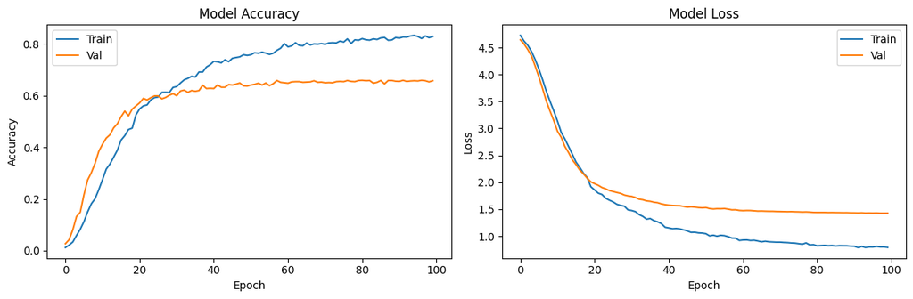

```python
import matplotlib.pyplot as plt

# Plot training & validation accuracy
plt.figure(figsize=(12, 4))
plt.subplot(1, 2, 1)
plt.plot(history.history['accuracy'], label='Train')
plt.plot(history.history['val_accuracy'], label='Val')
plt.title('Model Accuracy')
plt.xlabel('Epoch')
plt.ylabel('Accuracy')
plt.legend(loc='best')

# Plot training & validation loss
plt.subplot(1, 2, 2)
plt.plot(history.history['loss'], label='Train')
plt.plot(history.history['val_loss'], label='Val')
plt.title('Model Loss')
plt.xlabel('Epoch')
plt.ylabel('Loss')
plt.legend(loc='best')

plt.tight_layout()
plt.show()
```

```python
model.summary()
```

```
Model: "model"
_________________________________________________________________
 Layer (type)                Output Shape              Param #
=================================================================
 input_1 (InputLayer)        [(None, 224, 224, 3)]     0

 block1_conv1 (Conv2D)       (None, 224, 224, 64)      1792

 block1_conv2 (Conv2D)       (None, 224, 224, 64)      36928

 block1_pool (MaxPooling2D)  (None, 112, 112, 64)      0

 block2_conv1 (Conv2D)       (None, 112, 112, 128)     73856

 block2_conv2 (Conv2D)       (None, 112, 112, 128)     147584

 block2_pool (MaxPooling2D)  (None, 56, 56, 128)       0

 block3_conv1 (Conv2D)       (None, 56, 56, 256)       295168

 block3_conv2 (Conv2D)       (None, 56, 56, 256)       590080

 block3_conv3 (Conv2D)       (None, 56, 56, 256)       590080

 block3_pool (MaxPooling2D)  (None, 28, 28, 256)       0

 block4_conv1 (Conv2D)       (None, 28, 28, 512)       1180160

 block4_conv2 (Conv2D)       (None, 28, 28, 512)       2359808

 block4_conv3 (Conv2D)       (None, 28, 28, 512)       2359808

 block4_pool (MaxPooling2D)  (None, 14, 14, 512)       0

 block5_conv1 (Conv2D)       (None, 14, 14, 512)       2359808

 block5_conv2 (Conv2D)       (None, 14, 14, 512)       2359808

 block5_conv3 (Conv2D)       (None, 14, 14, 512)       2359808

 block5_pool (MaxPooling2D)  (None, 7, 7, 512)         0

 flatten (Flatten)           (None, 25088)             0

 dense (Dense)               (None, 512)               12845568

 dropout (Dropout)           (None, 512)               0

 dense_1 (Dense)             (None, 107)               54891

=================================================================
Total params: 27615147 (105.34 MB)
Trainable params: 12900459 (49.21 MB)
Non-trainable params: 14714688 (56.13 MB)
_________________________________________________________________
```

```python
import os

# Specify the directory in Google Drive where you want to save the models
save_directory = '/content/drive/My Drive/Colab Notebooks/Computer Vision and Deep Learning'
```

```python
# Save the transfer learning model
model.save(os.path.join(save_directory, 'transfer_model.keras'))
```

```python
# Save in .h5 format
model.save(os.path.join(save_directory, 'transfer_model.h5'))
```

```python
# Check TensorFlow version
import tensorflow as tf
print(tf.__version__)

# Check Keras version
import keras
print(keras.__version__)
```

```
2.15.0
2.15.0
```

```python
from google.colab import drive
import os

# Mount Google Drive
drive.mount('/content/drive')

# Define the path to the training directory
train_dir = "/content/drive/My Drive/Colab Notebooks/Computer Vision and Deep Learning/107 yoga poses/train"

# Get class labels from subdirectories
class_labels = sorted([folder for folder in os.listdir(train_dir) if os.path.isdir(os.path.join(train_dir, folder))])

# Print the class labels
print(class_labels)
```

[output not shown]

```python
len(class_labels)
```

```
107
```

# Compare the transfer learned models to my best custom model (from previous assignment) in their accuracy and other metrics.

# Previous custom model results are shown below

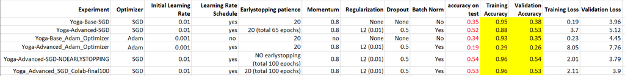

# The transfer learned model has higher validation accuracy (0.66), test accuracy (0.66), and lower validation loss (1.43) than the best custom model.

# Does transfer learning benefit this problem? Explain observations.

# Yes, transfer learning benefits this problem.

Transfer learning often results in better performance compared to training a custom Convolutional Neural Network (CNN) from scratch, especially when dealing with smaller datasets or limited computational resources. Here are reasons why a transfer learned model might have higher validation accuracy and lower validation loss compared to a custom CNN model:

1. Pre-trained Feature Extractors

Pre-trained models like VGG16, ResNet, or EfficientNet are trained on large and diverse datasets like ImageNet. They have already learned rich and hierarchical feature representations that are useful for a wide range of image recognition tasks. When use these pre-trained models, I leverage the feature extraction power of a network that has seen millions of images.

2. Better Generalization

Pre-trained models have a strong ability to generalize because they are exposed to a vast variety of images. **This generalization capability helps in transferring learned features to new, yet somewhat similar tasks, like the yoga pose classification**.

3. Avoiding Overfitting

Custom CNNs trained from scratch on a small dataset can easily overfit because they do not have enough data to learn robust features. Transfer learning mitigates this issue as the pre-trained weights provide a good starting point, reducing the need to learn all features from the limited training data.

4. Efficient Training

When fine-tune a pre-trained model, I freeze most of the earlier layers (which contain low-level features) and only train the higher layers (which contain more task-specific features). This makes training more efficient and requires fewer epochs to converge to a good solution.

5. Hyperparameter Optimization

Pre-trained models come with optimized architectures and hyperparameters that have been extensively validated on large-scale datasets. Custom CNNs, on the other hand, require careful tuning of architecture and hyperparameters, which can be challenging and time-consuming.

6. Robust Initialization

Pre-trained models provide a robust initialization, whereas training a custom CNN from scratch means starting from random weights. Good initialization helps in faster convergence and better final performance.